# Coverage Analysis

Will Hannon

1/29/2021

The goal of this notebook is to look at the coverage of reads over the SARS-CoV-2 genome for each deep-sequencing sample and replicate. The percentage of each genome covered by an adequate depth (100X) is assessed. Additionally, the pattern of read coverage is exmained.

## Completeness

This was the first exclusion criteria for samples in the experiment. They had to have at least 100 reads covering 80% of the genomes. Samples with less completeness were excluded. We know that depth/completeness impact how accuratley we can call variants. Samples with less completeness than this fail comparisons between the replicates anyhow.

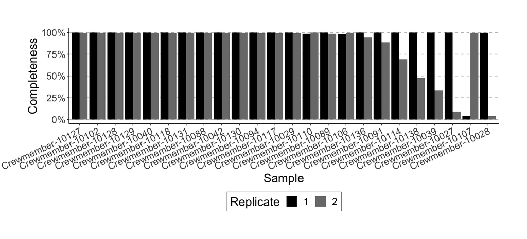

## Coverage Distribution

Next, I wanted to look at the pattern of coverage over the genome. To do this, I counted the number of reads in 50 BP bins over the genome using `samtools depth` and `AWK`.

The coverage pattern is pretty erratic since this isn’t amplicon sequencing - this is to be expected. Red samples are colored as those that don’t have more than 80% of the genome covered by more than 100 reads.

```
## [1] "There are 6 low coverage samples: "
```

```
## [1] "10027" "10114" "10028" "10138" "10039" "10107"
```

This leads to the exclusion of 6/24 crewmembers: 10027, 10114, 10028, 10138, 10039, and 10107

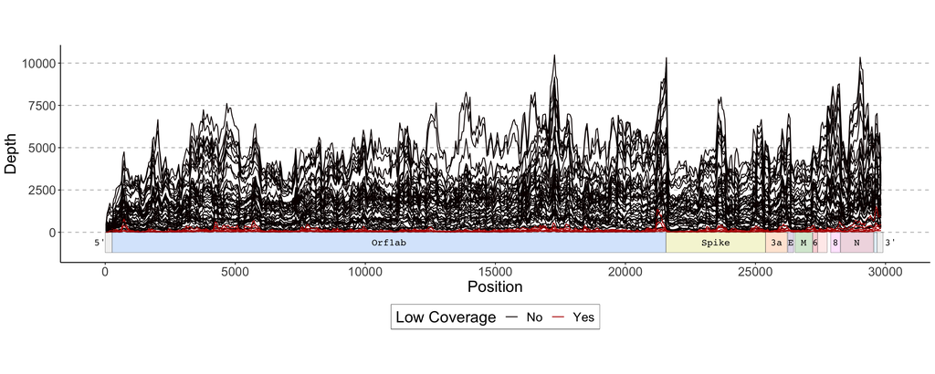

Below is the same plot as above, except that it’s split between the individual samples. The maximum number of reads is capped at 1000 reads and a line is drawn at 100X coverage, which was our requirement for minimum coverage.

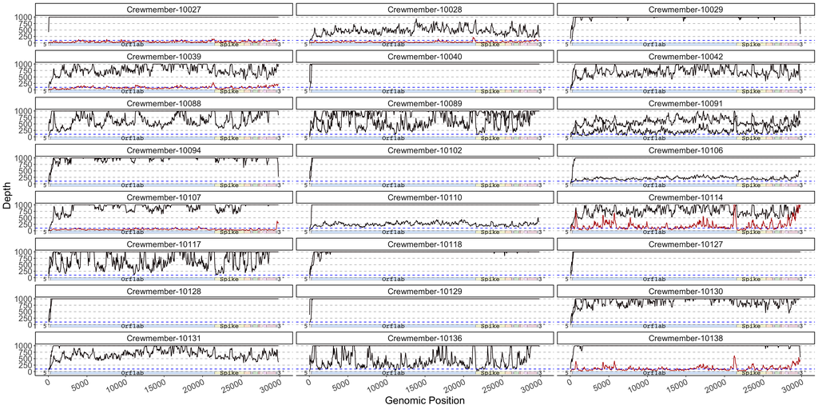